# KNN on Haberman’s Survival Dataset

Wayne Yang (waynejeyang@gmail.com)

UCI Machine Learning Databases

Relevant Information:

The dataset contains cases from a study that was conducted between 1958 and 1970 at the University of Chicago’s Billings Hospital on the survival of patients who had undergone surgery for breast cancer.

Aim for this project is to accurately predict survival rate of a patient who had undergone surgery for breast cancer by using the given attributes: Age, No. of positive axillary nodes attached, and Year of operation. These attributes are used to build a knn classification model.

```r
df <- read.table("file:///C:/Users/wayne/Desktop/Data Project/haberman.data.txt", header = FALSE, sep = ",")
head(df)
```

```
##   V1 V2 V3 V4
## 1 30 64  1  1
## 2 30 62  3  1
## 3 30 65  0  1
## 4 31 59  2  1
## 5 31 65  4  1
## 6 33 58 10  1
```

```r
names(df) <- c("Age", "Operation Year","No. of positive axillary nodes attached","Surivial status")
```

Importing data and renaming attributes.

```r
sum(is.na(df))
```

```
## [1] 0
```

```r
str(df)
```

```
## 'data.frame':    306 obs. of  4 variables:
##  $ Age                                    : int  30 30 30 31 31 33 33 34 34 34 ...
##  $ Operation Year                         : int  64 62 65 59 65 58 60 59 66 58 ...
##  $ No. of positive axillary nodes attached: int  1 3 0 2 4 10 0 0 9 30 ...
##  $ Surivial status                        : int  1 1 1 1 1 1 1 2 2 1 ...
```

```r
df$Age <- as.numeric(df$Age)
df$`No. of positive axillary nodes attached` <- as.numeric(df$`No. of positive axillary nodes attached`)
df$`Operation Year` <- as.numeric(df$`Operation Year`)
```

Checking for NA values and changing attributes to numeric format.

```r
set.seed(9850)
gp <- runif(nrow(df))
df <- df[order(gp),] #randomise data
head(df)
```

```
##     Age Operation Year No. of positive axillary nodes attached
## 216  59             62                                      35
## 103  47             67                                       0
## 20   37             63                                       0
## 268  65             67                                       1
## 167  53             63                                       0
## 63   43             58                                      52
##     Surivial status
## 216               2
## 103               1
## 20                1
## 268               1
## 167               1
## 63                2
```

Setting seed and randomising data so that it may be recalled. Randomising allows for the separation of the whole dataset into the training and testing model.

```r
normalise <- function(x) {
  + return((x - min(x)) / (max(x) - min(x)))}

normdf <- as.data.frame(lapply(df[,c(1,2,3)], normalise))
str(normdf)
```

```
## 'data.frame':    306 obs. of  3 variables:
##  $ Age                                    : num  0.547 0.321 0.132 0.66 0.434 ...
##  $ Operation.Year                         : num  0.364 0.818 0.455 0.818 0.455 ...
##  $ No..of.positive.axillary.nodes.attached: num  0.6731 0 0 0.0192 0 ...
```

```r
summary(normdf)
```

```
##       Age         Operation.Year   No..of.positive.axillary.nodes.attached
##  Min.   :0.0000   Min.   :0.0000   Min.   :0.00000
##  1st Qu.:0.2642   1st Qu.:0.1818   1st Qu.:0.00000
##  Median :0.4151   Median :0.4545   Median :0.01923
##  Mean   :0.4237   Mean   :0.4412   Mean   :0.07743
##  3rd Qu.:0.5802   3rd Qu.:0.7045   3rd Qu.:0.07692
##  Max.   :1.0000   Max.   :1.0000   Max.   :1.00000
```

Data is then normalised and applied to the 3 attritbutes to allow for valid classifcation using knn.

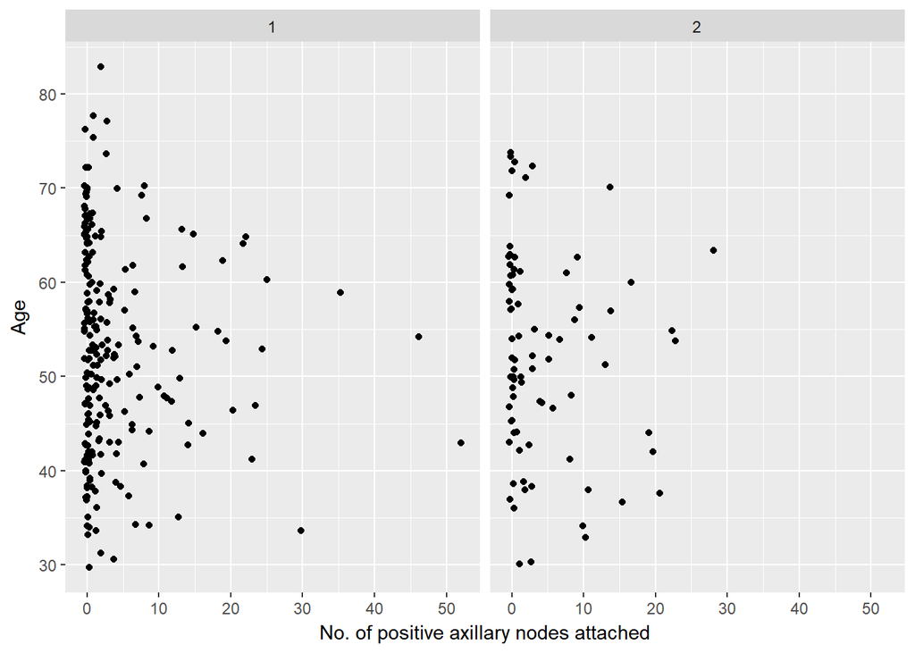

```r
library(ggplot2)
plot1 <- ggplot(data = df, aes(x = df$`No. of positive axillary nodes attached`, y = df$'Age')) +
  geom_jitter() +
  facet_grid(.~ df$`Surivial status`) +
  xlab("No. of positive axillary nodes attached") + ylab("Age")
plot1
```

```r
#1 = the patient survived 5 years or longer
#2 = the patient died within 5 years
```

Initial visualisation of data with Age and No. of positive axillary nodes attached as the y and x labels respectively. This was then split by survival status to visualise comparison.

```r
htrain <- normdf[1:205, ]
htest <- normdf[206:305, ]
trainiso <- df[1:205, 4]
testiso <- df[206:305, 4]
```

Train and test models are made with adequate data in each model.

```r
library(class)
ml1 <- knn(train = htrain, test = htest, cl = trainiso, k = 17)
ml1
```

```
##   [1] 1 1 1 1 1 1 1 1 1 1 1 1 1 1 1 1 1 1 1 1 2 2 1 1 1 1 1 1 1 1 1 1 2 1 1
##  [36] 1 1 1 2 1 1 1 1 1 1 1 1 1 1 1 1 1 1 1 1 1 1 2 1 1 2 1 1 1 1 1 1 1 1 1
##  [71] 1 1 1 1 1 1 1 1 1 1 1 1 1 1 1 1 1 1 1 1 1 1 1 1 1 1 1 1 1 1
## Levels: 1 2
```

Machine learning model is made with the training model against the test. K was approximately calculated by square rooting the total no. of observations.

```r
table(testiso, ml1)
```

```
##        ml1
## testiso  1  2
##       1 72  2
##       2 22  4
```

Table of results are shown above. We find that the model is 76% accurate in predicting the testing model.

Data setsource: (a) Donor: Tjen-Sien Lim (limt@stat.wisc.edu) (b) Date: March 4, 1999